[GitHub](https://github.com/Janssena/DeepCompartmentModels.jl)[](https://github.com/Janssena/DeepCompartmentModels.jl/blob/main/tutorials/06-custom-ode.qmd)

# Writing your own ODE model

*A transit-compartment absorption model beyond the built-in compartment models*

The built-in `one_comp!`, `one_comp_abs!`, `two_comp!` and `two_comp_abs!` cover the standard cases. Any other structure is just a Julia function. This tutorial writes a model with *transit-compartment absorption*, a common way to describe delayed absorption, fits it to the theophylline data, and compares it with the built-in `one_comp_abs!`.

```julia
using DeepCompartmentModels
using DataFrames, CSV
using CairoMakie
using Random

df = DataFrame(CSV.File(joinpath(pkgdir(DeepCompartmentModels), "data", "theophylline.csv")))
population = Population([begin
    obs = g[.!ismissing.(g.DV), :]
    cb = generate_dosing_callback([0.0 g.AMT[1] * g.WEIGHT[1]])
    Individual(g.ID[1], [g.WEIGHT[1]], obs.TIME, obs.DV, cb)
end for g in groupby(df, :ID)])
length(population)
```

```
12
```

## The conventions

An ODE function for a DCM is an ordinary in-place `OrdinaryDiffEq` function `f!(dA, A, p, t)` with three conventions:

1. **`p` is the parameter vector the network predicts, followed by the infusion rate `I`.** The dosing callback writes the current infusion rate into the *last* element of `p`. A model with `n` network outputs therefore reads `n + 1` values.
2. **Read `p` with `unpack(p, t)`.** For a plain vector this returns `p` unchanged. It also makes the function work with time-varying parameters.
3. **Drug enters through `I`.** Add `I` to the equation of the compartment where the dose is given, normally the first. Whether a state is an amount or a concentration is up to you: in `one_comp_abs!`, state 1 is an amount and state 2 a concentration (`/ V`), so `I` must be an amount per hour in state 1.

The built-in functions are written exactly like this, for example:

```julia
function one_comp_abs!(dA, A, p, t)
    kₐ, CL, Vd, I = unpack(p, t)
    k₁₀ = CL / Vd

    dA[1] = I - kₐ * A[1]
    dA[2] = (kₐ * A[1] / Vd) - A[2] * k₁₀
end
```

## A transit-compartment model

Instead of a single depot, the dose passes through a chain of transit compartments with the same rate constant `ktr` before it reaches the central compartment. One transit compartment gives:

```julia
function transit_abs!(dA, A, p, t)
    ktr, CL, V, I = unpack(p, t)

    dA[1] = I - ktr * A[1]               # depot
    dA[2] = ktr * A[1] - ktr * A[2]      # transit compartment
    dA[3] = ktr * A[2] / V - (CL / V) * A[3]   # central (concentration)
end
```

```
transit_abs! (generic function with 1 method)
```

Three states, so the problem needs `u0 = zeros(3)`, and the observations are state 3, so `target = 3`.

```julia
transit_problem = ODEProblem(transit_abs!, zeros(Float32, 3), (-0.1f0, 1f0); dt = 0.01f0)
```

```
ODEProblem with uType Vector{Float32} and tType Float32. In-place: true
Non-trivial mass matrix: false
timespan: (-0.1f0, 1.0f0)
u0: 3-element Vector{Float32}:
 0.0
 0.0
 0.0
```

Note

`DCM(transit_abs!, ann)` also works without an explicit problem. The number of states is then read off the function by looking for the highest index written with `dA[i] = ...`, which is convenient but a heuristic: if it guesses wrong, use `DCM(f!, n_states, ann)` or pass an `ODEProblem` as above.

## Fitting both models

The network predicts three positive parameters for both models, `ktr` or `kₐ`, `CL` and `V`:

```julia
make_ann() = Lux.Chain(
    Normalize([100f0]),
    Lux.Dense(1, 8, tanh),
    Lux.Dense(8, 3, Lux.softplus),
    Lux.WrappedFunction(x -> x .* Float32[1, 3, 30]),
)

builtin = DCM(ODEProblem(one_comp_abs!, zeros(Float32, 2), (-0.1f0, 1f0); dt = 0.01f0), make_ann(); target = 2)
transit = DCM(transit_problem, make_ann(); target = 3)
```

```julia
function train(objective, model, population, ps, st; epochs, lr)
    opt_state = Optimisers.setup(Optimisers.Adam(lr), ps)
    losses = Float32[]
    for _ in 1:epochs
        ∇ = gradient(objective, model, population, ps, st)
        opt_state, ps = Optimisers.update(opt_state, ps, ∇)
        push!(losses, objective(model, population, ps, st))
    end
    return ps, losses
end

fits = Dict()
for (name, model) in ["one_comp_abs!" => builtin, "transit_abs!" => transit]
    ps, st = setup(SSE(), Random.Xoshiro(1), model)
    ps, losses = train(SSE(), model, population, ps, st; epochs = 200, lr = 0.02f0)
    fits[name] = (; model, ps, st, losses)
end
DataFrame(model = collect(keys(fits)), SSE = [f.losses[end] for f in values(fits)])
```

2×2 DataFrame

| Row | model Any | SSE Float32 |
| --- | --- | --- |
| 1 | transit_abs! | 224.458 |
| 2 | one_comp_abs! | 227.411 |

Both fits use the same data, network and optimiser, so the difference in sum of squared errors reflects the structural model. Next the predicted curves for one subject:

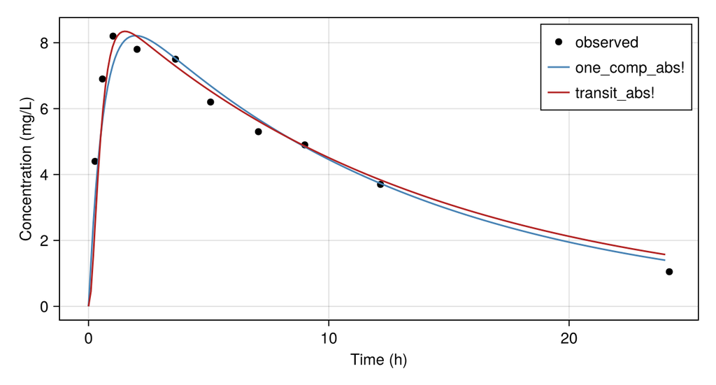

```julia
grid = Float32.(0:0.1:24)
indv = population[3]

fig = Figure(size = (650, 350))
ax = Axis(fig[1, 1]; xlabel = "Time (h)", ylabel = "Concentration (mg/L)")
scatter!(ax, get_t(indv), get_y(indv); color = :black, label = "observed")
for (name, color) in ["one_comp_abs!" => :steelblue, "transit_abs!" => :firebrick]
    f = fits[name]
    lines!(ax, grid, predict(f.model, indv, f.ps, f.st; saveat = grid); color, label = name)
end
axislegend(ax)
fig
```

## Predicting other states

`predict` returns the target state only. To get every state, for example to look at the amount in the transit compartment, pass `target = false`, which returns the ODE solution:

```julia
f = fits["transit_abs!"]
sols = predict(f.model, indv, f.ps, f.st; target = false, saveat = grid)
Array(sols)[1:3, [1, 20, 50, 100]]
```

```
3×4 Matrix{Float32}:
 0.0  0.223508  2.21995f-6  6.46892f-9
 0.0  1.6235    4.16673f-5  2.91722f-8
 0.0  8.2429    6.62023     4.54396
```

Each column is a time point, each row a compartment (depot, transit, central).

## Tips

- Everything the network outputs must be positive if it is used as a rate or volume. A `softplus` output layer is the simplest way to guarantee it.
- Scale the outputs of the network to a plausible range, as in the last layer above. Starting at the right order of magnitude matters more than the architecture.
- Fitting observations of more than one state, such as drug and effect, is not working in the current version, see Status and limitations.